# Programmation Différentiable et Optimisation : Implémentation et Évaluation

## 1. Introduction

Ce TP est une étude de plusieurs algorithmes d’optimisation, leur implémentation pratique, et leur évaluation dans le contexte de la programmation différentiable. Ces algorithmes sont cruciaux pour l’entraînement des modèles paramétriques, car ils ajustent les paramètres du modèle afin de minimiser la fonction de perte.

Les objectifs principaux de ce TP sont :

- Comprendre le fonctionnement de différents algorithmes d’optimisation.
- Implémenter et évaluer ces algorithmes dans des scénarios d’entraînement de réseaux de neurones.
- Explorer l'impact des schedulers de taux d'apprentissage sur la convergence des modèles.

Chaque algorithme sera évalué en minimisant des fonctions de perte convexes et non convexes, et en entraînant un réseau de neurones simple. Nous explorerons également l’utilisation de `LRScheduler` et de `LRSchedulerOnPlateau` pour ajuster dynamiquement le taux d’apprentissage afin d’optimiser la convergence du modèle.

## Importation des Bibliothèques

```python
import numpy as np
import matplotlib.pyplot as plt
from typing import Type, Tuple, List, Union, Literal
from tqdm import tqdm
```

## My Tensor

Dans cette section, nous définissons une classe `Tensor`, qui représente une variable tensorielle de base avec sa valeur (donnée) et son gradient. Cette classe est conçue pour être utilisée dans des calculs différentiables, permettant ainsi de suivre les gradients pendant l'entraînement de modèles paramétriques, comme les réseaux de neurones.

La classe `Tensor` contient plusieurs méthodes qui permettent d'effectuer des opérations sur des objets `Tensor`, comme l'addition, la multiplication, la puissance, et l'activation ReLU. Chaque opération est accompagnée d'un calcul de gradient via la méthode `backward`.

### Attributs

- **data** : La valeur du tensor (un scalaire).
- **grad** : Le gradient du tensor, initialisé à 0.
- **_prev** : Un ensemble qui stocke les tensors précédents nécessaires pour la rétropropagation.
- **_op** : L'opération ayant généré ce tensor (par exemple `+`, `*`, etc.).

### Méthodes

1. **Addition (`__add__`)** : Effectue l'addition de deux tensors.
2. **Multiplication (`__mul__`)** : Effectue la multiplication de deux tensors.
3. **Puissance (`__pow__`)** : Permet d'élever un tensor à une puissance spécifiée.
4. **ReLU (`relu`)** : Applique la fonction d'activation ReLU, qui met à zéro les valeurs négatives.
5. **`backward()`** : Calcule les gradients de tous les tensors dans le graphe de computation en utilisant la méthode de rétropropagation.

```python
class Tensor:

    """ stores a single scalar Tensor and its gradient """

    def __init__(self, data, _children=(), _op=''):

        self.data = data
        self.grad = 0.0

        self._backward = lambda: None
        self._prev = set(_children)
        self._op = _op

    def __add__(self, other):
        other = other if isinstance(other, Tensor) else Tensor(other)

        out = Tensor(self.data + other.data, (self, other), '+')

        def _backward():
            self.grad += out.grad
            other.grad += out.grad

        out._backward = _backward

        out._prev = set([self, other])
        return out

    def __mul__(self, other):

        other = other if isinstance(other, Tensor) else Tensor(other)

        out = Tensor(self.data * other.data, [self, other], '*')

        def _backward():
            self.grad += other.data * out.grad
            if other.data != 0:
                other.grad += self.data * out.grad
            else:
                other.grad = 0
        out._backward = _backward

        return out

    def __pow__(self, other):

        assert isinstance(other, (int, float)), "only supporting int/float powers for now"

        out = Tensor(self.data**other, (self,), f'**{other}')

        def _backward():
            self.grad += (other * self.data**(other-1)) * out.grad

        out._backward = _backward

        return out

    def relu(self):
        out = Tensor(0 if self.data < 0 else self.data, [self], 'ReLU')
        def _backward():
            self.grad += out.grad
        out._backward = _backward
        return out

    def build_topo(self, visited=None, topo=None):
        if self not in visited:
            visited.add(self)
            for child in self._prev:
                child.build_topo(visited=visited, topo=topo)
            topo.append(self)
        return topo

    def backward(self):
        topo = []
        visited = set()
        topo = self.build_topo(topo=topo, visited=visited)

        self.grad = 1.0
        for v in reversed(topo):
            v._backward()

    def __neg__(self): # -self
        return self * -1

    def __radd__(self, other):
        return self + other

    def __sub__(self, other):
        return self + (-other)

    def __rsub__(self, other):
        return other + (-self)

    def __rmul__(self, other):
        return self * other

    def __truediv__(self, other):
        return self * other**-1

    def __rtruediv__(self, other):
        return other * self**-1

    def __repr__(self):
        return f"Tensor(data={self.data}, grad={self.grad})"
```

## 3. Jeux de Données Synthétiques

Pour ce TP, nous utiliserons deux jeux de données synthétiques : un jeu linéaire et un jeu non linéaire. Ces jeux de données permettront d’évaluer les performances des algorithmes d’optimisation et des schedulers de taux d’apprentissage dans des contextes différents.

### 3.1 Jeu de Données Linéaire

Le jeu de données linéaire est généré à partir d’une relation linéaire entre les variables `x` et `y` avec l’ajout d’un bruit gaussien.

```python
np.random.seed(0)
n_samples = 100
x_linear = np.linspace(-10, 10, n_samples)
y_linear = 3 * x_linear + 5 + np.random.normal(0, 2, n_samples)
```

### 3.2 Jeu de Données Non Linéaire

Le jeu de données non linéaire est basé sur une relation quadratique entre `x` et `y` avec un bruit ajouté.

```python
y_nonlinear = 0.5 * x_linear**2- 4 * x_linear + np.random.normal(0, 5, n_samples)
```

# 4. Présentation des Algorithmes

## Classe `Optimizer`

La classe `Optimizer` est la classe de base pour les algorithmes d'optimisation. Elle permet de gérer les paramètres à optimiser et leur mise à jour pendant l'entraînement d'un modèle. Elle prend en charge l'initialisation des paramètres, la réinitialisation des gradients à zéro, et la mise à jour des paramètres (qui doit être implémentée dans les sous-classes spécifiques comme SGD ou Adam).

- **params** : Les paramètres à optimiser (peuvent être une liste ou un objet).
- **learning_rate** : Le taux d'apprentissage pour l'optimisation.

Chaque sous-classe d'optimiseur héritera de cette classe et y ajoutera sa logique spécifique pour ajuster les paramètres.

```python
class Optimizer:
    """
    Base class for optimization algorithms.

    This class provides a simple framework for managing parameter updates
    during training.

    Attributes:
        params (Union[List, object]): A list of parameters or a single parameter object.
        learning_rate (float): The learning rate for the optimizer.
    """

    def __init__(self, params: Union[List[object], object], learning_rate: float = 0.01) -> None:
        """
        Initializes the Optimizer with parameters and a learning rate.

        Args:
            params (Union[List[object], object]): Parameters to optimize. Can be a list or a single object.
            learning_rate (float): Learning rate for the optimization algorithm. Default is 0.01.
        """
        self.params = params
        self.learning_rate = learning_rate

    def zeros_grad(self) -> None:
        """
        Resets the gradients of the parameters to zero.
        """
        if isinstance(self.params, list):
            for param in self.params:
                param.grad = 0
        else:
            self.params.grad = 0

    def step(self) -> None:
        """
        Updates the parameters based on their gradients and the learning rate.

        Note:
            This method should be implemented in subclasses for specific optimization algorithms.
        """
        ...
```

### 4.1 Stochastic Gradient Descent (SGD)

La méthode SGD met à jour les paramètres du modèle en fonction du gradient de la fonction de perte par rapport aux paramètres.

Formule :

θ(t+1) = θ(t) - η ∇θ L(θt)

```python
class SGD(Optimizer):
    """
    Stochastic Gradient Descent (SGD) optimizer.

    This class implements the SGD optimization algorithm, which updates
    parameters using their gradients and a fixed learning rate.

    Attributes:
        params (Union[List[object], object]): Parameters to optimize.
        learning_rate (float): The learning rate for the optimizer.
    """

    def __init__(self, params: Union[List[object], object], learning_rate: float = 0.01, **kwargs) -> None:
        """
        Initializes the SGD optimizer with parameters, a learning rate, and additional options.

        Args:
            params (Union[List[object], object]): Parameters to optimize. Can be a list or a single object.
            learning_rate (float): Learning rate for the optimization algorithm. Default is 0.01.
            **kwargs: Additional arguments (reserved for future extensions or compatibility).
        """
        super().__init__(params, learning_rate)

    def step(self) -> None:
        """
        Performs a single optimization step.

        Updates the parameters by subtracting the product of the learning rate
        and their respective gradients.

        Raises:
            AttributeError: If a parameter does not have `data` or `grad` attributes.
        """
        for param in self.params:
            param.data -= self.learning_rate * param.grad
```

### 4.2 RMSProp

RMSProp adapte le taux d’apprentissage pour chaque paramètre en fonction de la moyenne des carrés des gradients passés.

Formule :

θ(t+1) = θ(t) - (η/√(Eg² + ε)) ∇θ L(θt)

```python
class RMSProp(Optimizer):
    """
    RMSProp optimizer.

    This class implements the RMSProp optimization algorithm, which adjusts
    the learning rate for each parameter individually using a moving average
    of squared gradients.

    Attributes:
        params (Union[List[object], object]): Parameters to optimize.
        learning_rate (float): The learning rate for the optimizer.
        decay (float): The decay rate for the moving average of squared gradients.
        epsilon (float): A small value to prevent division by zero.
        g (List[float]): Moving average of squared gradients for each parameter.
    """

    def __init__(
        self,
        params: Union[List[object], object],
        learning_rate: float = 0.01,
        decay: float = 0.9,
        epsilon: float = 1e-8,
        **kwargs
    ) -> None:
        """
        Initializes the RMSProp optimizer.

        Args:
            params (Union[List[object], object]): Parameters to optimize. Can be a list or a single object.
            learning_rate (float): Learning rate for the optimization algorithm. Default is 0.01.
            decay (float): Decay rate for the moving average of squared gradients. Default is 0.9.
            epsilon (float): A small value to prevent division by zero. Default is 1e-8.
            **kwargs: Additional arguments (reserved for future extensions or compatibility).
        """
        super().__init__(params, learning_rate)
        self.decay = decay
        self.epsilon = epsilon
        self.g = [0.0 for _ in (self.params if isinstance(self.params, list) else [self.params])]

    def step(self) -> None:
        """
        Performs a single optimization step.

        Updates the parameters by adjusting their learning rate based on the
        moving average of squared gradients.

        Raises:
            AttributeError: If a parameter does not have `data` or `grad` attributes.
        """
        for i, param in enumerate(self.params if isinstance(self.params, list) else [self.params]):
            self.g[i] = self.decay * self.g[i] + (1 - self.decay) * param.grad ** 2
            param.data -= (self.learning_rate / (np.sqrt(self.g[i]) + self.epsilon)) * param.grad
```

### 4.3 Adagrad

Adagrad ajuste le taux d’apprentissage pour chaque paramètre en fonction des gradients passés, favorisant des mises à jour plus importantes pour les paramètres moins fréquemment mis à jour.

Formule :

θ(t+1) = θ(t) - (η/√(G(t) + ε)) ∇θ L(θt)

```python
class Adagrad(Optimizer):
    """
    Adagrad optimizer.

    This class implements the Adagrad optimization algorithm, which adapts
    the learning rate for each parameter based on the cumulative sum of
    squared gradients.

    Attributes:
        params (Union[List[object], object]): Parameters to optimize.
        learning_rate (float): The learning rate for the optimizer.
        epsilon (float): A small value to prevent division by zero.
        gt (List[float]): Cumulative sum of squared gradients for each parameter.
    """

    def __init__(
        self,
        params: Union[List[object], object],
        learning_rate: float = 0.01,
        epsilon: float = 1e-8,
        **kwargs
    ) -> None:
        """
        Initializes the Adagrad optimizer.

        Args:
            params (Union[List[object], object]): Parameters to optimize. Can be a list or a single object.
            learning_rate (float): Learning rate for the optimization algorithm.
            epsilon (float): A small value to prevent division by zero. Default is 1e-8.
            **kwargs: Additional arguments (reserved for future extensions or compatibility).
        """
        super().__init__(params, learning_rate)
        self.epsilon = epsilon
        self.gt = [0.0 for _ in (self.params if isinstance(self.params, list) else [self.params])]

    def step(self) -> None:
        """
        Performs a single optimization step.

        Updates the parameters by adjusting their learning rate based on the
        cumulative sum of squared gradients.

        Raises:
            AttributeError: If a parameter does not have `data` or `grad` attributes.
        """
        for i, param in enumerate(self.params if isinstance(self.params, list) else [self.params]):
            grad = param.grad
            self.gt[i] += grad ** 2
            param.data -= self.learning_rate / np.sqrt(self.gt[i] + self.epsilon) * grad
```

### 4.4 Adam

Adam combine les avantages de RMSProp et de Momentum en utilisant des moments exponentiels pour estimer les premiers et seconds moments des gradients.

Formules :

m(t) = β₁m(t-1) + (1-β₁)∇θ L(θt)

v(t) = β₂v(t-1) + (1-β₂)(∇θ L(θt))²

θ(t+1) = θ(t) - (η/√(v̂(t) + ε))m̂(t)

```python
class Adam(Optimizer):
    """
    Adam optimizer.

    This class implements the Adam optimization algorithm, which combines
    the advantages of RMSProp and momentum-based optimization.

    Attributes:
        params (Union[List[object], object]): Parameters to optimize.
        learning_rate (float): The learning rate for the optimizer.
        beta1 (float): Coefficient for computing running averages of gradients. Default is 0.9.
        beta2 (float): Coefficient for computing running averages of squared gradients. Default is 0.999.
        eps (float): A small value to prevent division by zero. Default is 1e-8.
        m (List[float]): Exponential moving averages of gradients for each parameter.
        v (List[float]): Exponential moving averages of squared gradients for each parameter.
    """

    def __init__(
        self,
        params: Union[List[object], object],
        learning_rate: float = 0.001,
        beta1: float = 0.9,
        beta2: float = 0.999,
        eps: float = 1e-8,
        **kwargs
    ) -> None:
        """
        Initializes the Adam optimizer.

        Args:
            params (Union[List[object], object]): Parameters to optimize. Can be a list or a single object.
            learning_rate (float): Learning rate for the optimization algorithm. Default is 0.001.
            beta1 (float): Coefficient for computing running averages of gradients. Default is 0.9.
            beta2 (float): Coefficient for computing running averages of squared gradients. Default is 0.999.
            eps (float): A small value to prevent division by zero. Default is 1e-8.
            **kwargs: Additional arguments (reserved for future extensions or compatibility).
        """
        super().__init__(params, learning_rate)
        self.beta1 = beta1
        self.beta2 = beta2
        self.eps = eps
        self.m = [0.0 for _ in (self.params if isinstance(self.params, list) else [self.params])]
        self.v = [0.0 for _ in (self.params if isinstance(self.params, list) else [self.params])]

    def step(self) -> None:
        """
        Performs a single optimization step.

        Updates the parameters using the Adam optimization algorithm, which
        combines first- and second-moment estimates of the gradients.

        Raises:
            AttributeError: If a parameter does not have `data` or `grad` attributes.
        """
        for i, param in enumerate(self.params if isinstance(self.params, list) else [self.params]):
            grad = param.grad
            self.m[i] = self.beta1 * self.m[i] + (1 - self.beta1) * grad
            self.v[i] = self.beta2 * self.v[i] + (1 - self.beta2) * (grad ** 2)
            param.data -= self.learning_rate / (np.sqrt(self.v[i]) + self.eps) * self.m[i]
```

### 4.5 AdamW

AdamW est une variante d'Adam qui ajoute une régularisation L2 pour améliorer la généralisation.

```python
class AdamW(Optimizer):
    """
    AdamW optimizer.

    This class implements the AdamW optimization algorithm, which is a variant
    of Adam that decouples weight decay from the gradient-based optimization.

    Attributes:
        params (Union[List[object], object]): Parameters to optimize.
        learning_rate (float): The learning rate for the optimizer.
        beta1 (float): Coefficient for computing running averages of gradients. Default is 0.9.
        beta2 (float): Coefficient for computing running averages of squared gradients. Default is 0.999.
        eps (float): A small value to prevent division by zero. Default is 1e-8.
        weight_decay (float): Weight decay coefficient for regularization. Default is 1e-2.
        m (List[float]): Exponential moving averages of gradients for each parameter.
        v (List[float]): Exponential moving averages of squared gradients for each parameter.
    """

    def __init__(
        self,
        params: Union[List[object], object],
        learning_rate: float = 0.001,
        beta1: float = 0.9,
        beta2: float = 0.999,
        eps: float = 1e-8,
        weight_decay: float = 1e-2,
        **kwargs
    ) -> None:
        """
        Initializes the AdamW optimizer.

        Args:
            params (Union[List[object], object]): Parameters to optimize. Can be a list or a single object.
            learning_rate (float): Learning rate for the optimization algorithm. Default is 0.001.
            beta1 (float): Coefficient for computing running averages of gradients. Default is 0.9.
            beta2 (float): Coefficient for computing running averages of squared gradients. Default is 0.999.
            eps (float): A small value to prevent division by zero. Default is 1e-8.
            weight_decay (float): Weight decay coefficient for regularization. Default is 1e-2.
            **kwargs: Additional arguments (reserved for future extensions or compatibility).
        """
        super().__init__(params, learning_rate)
        self.beta1 = beta1
        self.beta2 = beta2
        self.eps = eps
        self.weight_decay = weight_decay
        self.m = [0.0 for _ in (self.params if isinstance(self.params, list) else [self.params])]
        self.v = [0.0 for _ in (self.params if isinstance(self.params, list) else [self.params])]

    def step(self) -> None:
        """
        Performs a single optimization step.

        Updates the parameters using the AdamW optimization algorithm, which
        incorporates weight decay directly into the parameter updates.

        Raises:
            AttributeError: If a parameter does not have `data` or `grad` attributes.
        """
        for i, param in enumerate(self.params if isinstance(self.params, list) else [self.params]):
            grad = param.grad
            # Compute weight-decayed gradient
            grad += self.weight_decay * param.data
            # Update moving averages
            self.m[i] = self.beta1 * self.m[i] + (1 - self.beta1) * grad
            self.v[i] = self.beta2 * self.v[i] + (1 - self.beta2) * (grad ** 2)
            # Update parameter data
            param.data -= self.learning_rate / (np.sqrt(self.v[i]) + self.eps) * self.m[i]
```

## 5. Évaluation des Optimiseurs

### 5.1 Fonctions de Perte

```python
def f(x: float) -> float:
    """
    A simple convex quadratic function.

    Args:
        x (float): Input value.

    Returns:
        float: The result of the function (x - 2)^2.
    """
    return (x - 2) ** 2

def f_nonconvexe(x: float) -> float:
    """
    A simple non-convex function.

    Args:
        x (float): Input value.

    Returns:
        float: The result of the function 3x^2 - 2x.
    """
    return 3 * x**2 - 2 * x
```

### 5.2 Expérimentation

```python
NB_ITER = 200
LEARNING_RATE = 1e-3
EPSILON = 1e-8
DECAY = 0.9
BETA1 = 0.9
BETA2 = 0.999
WEIGHT_DECAY = 1
```

```python
def eval_optim(
    optimizer_kwargs: dict,
    nb_iter: int,
    start_value: float = 0.0,
    optimizer_type: Type[Optimizer] = SGD
) -> Tuple[List[float], List[float]]:
    """
    Evaluates the performance of an optimization algorithm on a convex function.

    Args:
        optimizer_kwargs (dict): Arguments to initialize the optimizer.
        nb_iter (int): Number of optimization iterations.
        start_value (float): Starting value for the optimization. Default is 0.0.
        optimizer_type (Type[Optimizer]): The optimizer class to use. Default is SGD.

    Returns:
        Tuple[List[float], List[float]]: A tuple containing:
            - A list of parameter values at each iteration (`xs`).
            - A list of loss values at each iteration (`losses`).
    """
    xs = []
    losses = []
    x = Tensor(start_value)
    optimizer = optimizer_type([x], **optimizer_kwargs)
    for _ in range(nb_iter):
        optimizer.zeros_grad()
        loss = f(x)
        loss.backward()
        optimizer.step()
        xs.append(x.data)
        losses.append(loss.data)
    return xs, losses
```

## 6. Réseau de Neurones

### 6.1 Définition du Modèle

Un réseau de neurones simple avec une couche cachée est défini, ainsi que la fonction de perte MSE (Mean Squared Error).

```python
def func_nn(
    x: Union[float, Tensor],
    W1: Tensor,
    b1: Tensor,
    W2: Tensor,
    b2: Tensor
) -> Tensor:
    """
    A simple feed-forward neural network with one hidden layer.

    Args:
        x (Union[float, Tensor]): Input value, either a scalar (float) or a Tensor.
        W1 (Tensor): Weights of the first layer.
        b1 (Tensor): Bias of the first layer.
        W2 (Tensor): Weights of the second layer.
        b2 (Tensor): Bias of the second layer.

    Returns:
        Tensor: The output of the network after applying linear transformation,
                ReLU activation, and a second linear transformation.
    """
    x = Tensor(x)  # Ensures input is a Tensor.
    h1 = W1 * x + b1  # First layer computation.
    h1 = h1.relu()  # Apply ReLU activation.
    y = W2 * h1 + b2  # Second layer computation.
    return y

def mse(y: Tensor, y_hat: Tensor) -> Tensor:
    """
    Mean Squared Error (MSE) loss function.

    Args:
        y (Tensor): True labels.
        y_hat (Tensor): Predicted labels.

    Returns:
        Tensor: The MSE loss computed as the squared difference between
                true and predicted values.
    """
    return (y - y_hat) ** 2  # MSE loss computation.
```

### 6.2 Entraînement du Réseau

L’entraînement du réseau de neurones est effectué en utilisant des données générées, et les performances sont évaluées pour différents optimiseurs.

```python
def eval_nn_optim(
    x: List[Union[float, Tensor]],
    y: List[Union[float, Tensor]],
    optimizer_kwargs: dict,
    nb_iter: int,
    optimizer_type: Type[Optimizer] = SGD
) -> Tuple[Tensor, Tensor, Tensor, Tensor, List[float]]:
    """
    Evaluates the performance of an optimizer on a simple neural network.

    Args:
        x (List[Union[float, Tensor]]): Input data.
        y (List[Union[float, Tensor]]): True labels (targets).
        optimizer_kwargs (dict): Arguments to initialize the optimizer.
        nb_iter (int): Number of optimization iterations.
        optimizer_type (Type[Optimizer]): The optimizer class to use. Default is SGD.

    Returns:
        Tuple[Tensor, Tensor, Tensor, Tensor, List[float]]: A tuple containing:
            - The learned weights and biases: W1, b1, W2, b2.
            - A list of the average loss values at each iteration.
    """
    # Initialize parameters with random normal values.
    W1, b1 = Tensor(np.random.normal()), Tensor(np.random.normal())
    W2, b2 = Tensor(np.random.normal()), Tensor(np.random.normal())

    # Initialize optimizer with parameters and optimizer arguments.
    optimizer = optimizer_type([W1, b1, W2, b2], **optimizer_kwargs)

    losses = []

    for _ in tqdm(range(nb_iter)):
        total_loss = 0
        for i in range(len(x)):
            optimizer.zeros_grad()  # Zero the gradients.
            y_pred = func_nn(x[i], W1, b1, W2, b2)  # Forward pass.
            loss = mse(y[i], y_pred)  # Compute loss.
            loss.backward()  # Backpropagate the gradients.
            total_loss += loss.data  # Accumulate loss.
            optimizer.step()  # Update parameters.

        avg_loss = total_loss / len(x)  # Calculate average loss.
        losses.append(avg_loss)

    return W1, b1, W2, b2, losses
```

## 7. Scheduler de Taux d'Apprentissage

### 7.1 LRScheduler

Le `LRScheduler` ajuste le taux d’apprentissage en fonction des métriques observées pendant l’entraînement.

```python
class LRScheduler:
    """
    Learning Rate Scheduler.

    This class provides a mechanism to adjust the learning rate during training.

    Attributes:
        optimizer (Optimizer): The optimizer whose learning rate is being adjusted.
        learning_rate (float): The current learning rate.

    Methods:
        get_last_lr() -> float:
            Returns the last used learning rate.
        get_lr() -> float:
            Returns the current learning rate based on the scheduling rule.
        step() -> None:
            Updates the learning rate using `get_lr()` and applies it to the optimizer.
    """

    def __init__(self, optimizer: Optimizer, initial_lr: float) -> None:
        """
        Initializes the learning rate scheduler.

        Args:
            optimizer (Optimizer): The optimizer to adjust the learning rate for.
            initial_lr (float): The initial learning rate to use.
        """
        self.optimizer = optimizer
        self.learning_rate = initial_lr

    def get_last_lr(self) -> float:
        """
        Returns the last used learning rate.

        Returns:
            float: The last learning rate used by the scheduler.
        """
        return self.learning_rate

    def get_lr(self) -> float:
        """
        Computes and returns the current learning rate.

        This method should be overridden in a subclass to implement the
        specific learning rate adjustment logic.

        Returns:
            float: The current learning rate.
        """
        raise NotImplementedError("This method should be overridden by subclasses.")

    def step(self) -> None:
        """
        Updates the learning rate based on `get_lr()` and applies it to the optimizer.

        This method should be called at each training step to adjust the learning rate.
        """
        self.learning_rate = self.get_lr()
        self.optimizer.learning_rate = self.learning_rate
```

### 7.2 LRSchedulerOnPlateau

Cette classe ajuste le taux d’apprentissage en fonction de l’absence d’amélioration sur un certain nombre d’époques.

```python
class LRSchedulerOnPlateau(LRScheduler):
    """
    Learning Rate Scheduler that reduces the learning rate when the validation loss plateaus.

    This class adjusts the learning rate based on the validation loss. If the validation loss
    does not improve for a specified number of iterations (patience), the learning rate is reduced
    by a specified factor.

    Attributes:
        patience (int): The number of iterations with no improvement before reducing the learning rate.
        factor (float): The factor by which the learning rate is multiplied when it is reduced.
        min_lr (float): The minimum learning rate that can be reached.
        mode (Literal['min', 'max']): Whether to monitor the validation loss for a minimum ('min') or maximum ('max').
        threshold (float): The threshold for considering an improvement in validation loss.
        min_loss (float or None): The best validation loss observed so far, adjusted by the threshold.
        bad_loss (int): The number of consecutive epochs without improvement in the validation loss.

    Methods:
        get_lr(val_loss: float) -> float:
            Computes the new learning rate based on the validation loss.
        step(val_loss: float) -> None:
            Updates the learning rate based on the validation loss and applies it to the optimizer.
    """

    def __init__(
        self,
        optimizer: Optimizer,
        initial_lr: float,
        patience: int = 10,
        factor: float = 0.1,
        min_lr: float = 1e-6,
        mode: Literal['min', 'max'] = 'min',
        threshold: float = 1e-4
    ) -> None:
        """
        Initializes the LRSchedulerOnPlateau.

        Args:
            optimizer (Optimizer): The optimizer to adjust the learning rate for.
            initial_lr (float): The initial learning rate to use.
            patience (int, optional): The number of iterations with no improvement before reducing the learning rate. Default is 10.
            factor (float, optional): The factor by which to reduce the learning rate. Default is 0.1.
            min_lr (float, optional): The minimum learning rate. Default is 1e-6.
            mode (Literal['min', 'max'], optional): Whether to monitor for 'min' or 'max' validation loss. Default is 'min'.
            threshold (float, optional): The threshold for improvement in validation loss. Default is 1e-4.
        """
        super().__init__(optimizer, initial_lr)
        self.patience = patience
        self.factor = factor
        self.min_lr = min_lr
        self.mode = mode
        self.threshold = threshold
        self.min_loss = None
        self.bad_loss = 0

    def get_lr(self, val_loss: float) -> float:
        """
        Computes the new learning rate based on the validation loss.

        If the validation loss does not improve for a number of iterations defined by `patience`,
        the learning rate is reduced by the `factor`.

        Args:
            val_loss (float): The current validation loss.

        Returns:
            float: The updated learning rate.
        """
        lr = self.learning_rate
        if self.mode == 'max':
            val_loss = -val_loss  # In case we're maximizing, invert the loss.

        if self.min_loss is None:
            self.min_loss = val_loss - self.threshold
        elif val_loss < self.min_loss:
            self.bad_loss = 0
            self.min_loss = val_loss - self.threshold
        else:
            self.bad_loss += 1

        if self.bad_loss > self.patience and self.learning_rate > self.min_lr:
            self.bad_loss = 0
            lr = self.learning_rate * self.factor  # Reduce learning rate.

        return lr

    def step(self, val_loss: float) -> None:
        """
        Updates the learning rate based on the validation loss and applies it to the optimizer.

        Args:
            val_loss (float): The current validation loss used to adjust the learning rate.
        """
        self.learning_rate = self.get_lr(val_loss)
        self.optimizer.learning_rate = self.learning_rate
```

## 8. Tests et Visualisations

#### Évaluation des Optimiseurs sur (x-2)^2

On compare différents optimiseurs (SGD, RMSProp, Adagrad, Adam, AdamW) pour minimiser (x-2)^2.

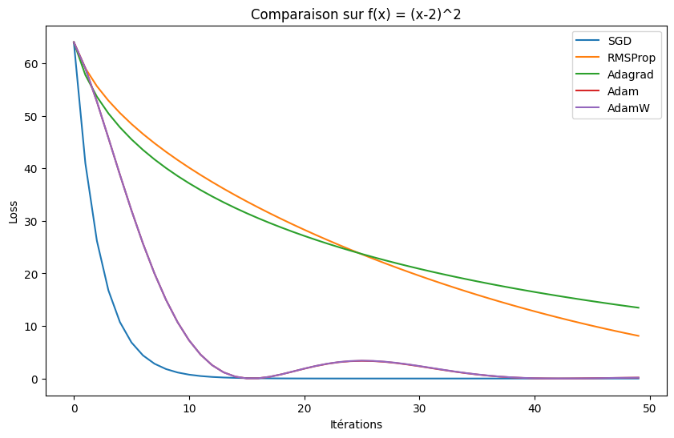

```python
optimizers_to_test = {
    "SGD":      {"optimizer_type": SGD,      "optimizer_kwargs": {"learning_rate": 0.1}},
    "RMSProp":  {"optimizer_type": RMSProp,  "optimizer_kwargs": {"learning_rate": 0.1}},
    "Adagrad":  {"optimizer_type": Adagrad,  "optimizer_kwargs": {"learning_rate": 0.4}},
    "Adam":     {"optimizer_type": Adam,     "optimizer_kwargs": {"learning_rate": 0.1}},
    "AdamW":    {"optimizer_type": AdamW,    "optimizer_kwargs": {"learning_rate": 0.1}},
}

plt.figure(figsize=(10,6))
nb_iter = 50
start_value = 10.0

for name, config in optimizers_to_test.items():
    xs, losses = eval_optim(
        optimizer_kwargs=config["optimizer_kwargs"],
        nb_iter=nb_iter,
        start_value=start_value,
        optimizer_type=config["optimizer_type"]
    )
    plt.plot(losses, label=name)

plt.title("Comparaison sur f(x) = (x-2)^2")
plt.xlabel("Itérations")
plt.ylabel("Loss")
plt.legend()
plt.show()
```

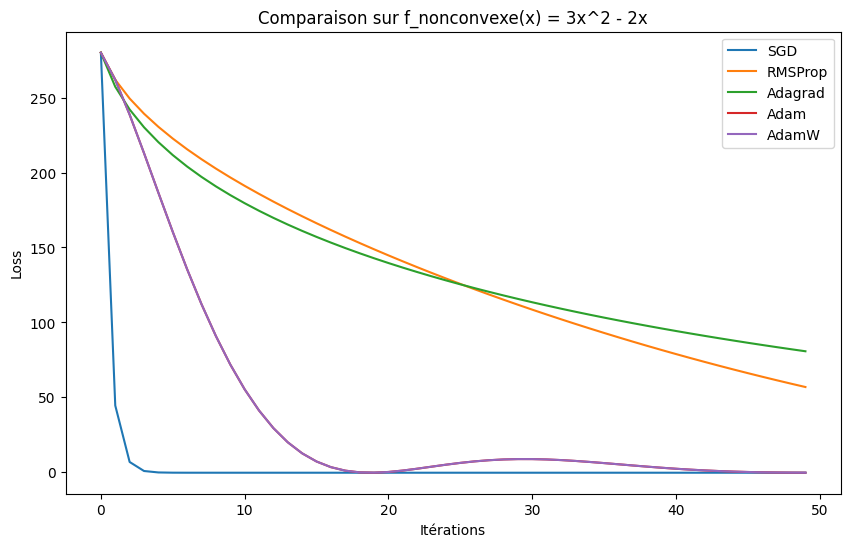

```python
plt.figure(figsize=(10,6))

for name, config in optimizers_to_test.items():
    xs_nc, losses_nc = eval_optim_nonconvexe(
        optimizer_kwargs=config["optimizer_kwargs"],
        nb_iter=nb_iter,
        start_value=start_value,
        optimizer_type=config["optimizer_type"]
    )
    plt.plot(losses_nc, label=name)

plt.title("Comparaison sur f_nonconvexe(x) = 3x^2 - 2x")
plt.xlabel("Itérations")
plt.ylabel("Loss")
plt.legend()
plt.show()
```

### 1. Entraînement sur les données linéaires

Dans cette première expérience, on va entraîner le réseau de neurones sur les données linéaires (x_linear, y_linear). On affichera ensuite : 1. L’évolution de la loss au fil des itérations. 2. La droite (ou la fonction) apprise par le réseau en la comparant aux données.

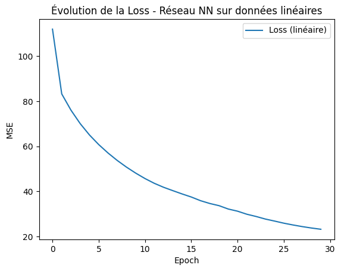

```
Paramètres appris (Données Linéaires) :
W1 = 1.4821, b1 = 5.4279
W2 = 2.8485, b2 = -11.0630
```

```python
nb_iter_nn = 30
optimizer_kwargs_nn = {"learning_rate": 0.001}
optimizer_type_nn = SGD

W1_lin, b1_lin, W2_lin, b2_lin, losses_lin = eval_nn_optim(
    x_linear,
    y_linear,
    optimizer_kwargs=optimizer_kwargs_nn,
    nb_iter=nb_iter_nn,
    optimizer_type=optimizer_type_nn
)

plt.figure()
plt.plot(losses_lin, label="Loss (linéaire)")
plt.title("Évolution de la Loss - Réseau NN sur données linéaires")
plt.xlabel("Epoch")
plt.ylabel("MSE")
plt.legend()
plt.show()

print("Paramètres appris (Données Linéaires) :")
print(f"W1 = {W1_lin.data:.4f}, b1 = {b1_lin.data:.4f}")
print(f"W2 = {W2_lin.data:.4f}, b2 = {b2_lin.data:.4f}")
```

### 1.1 Visualisation de la fonction apprise

On génère un ensemble de points x_test couvrant l’intervalle [-10,10] pour voir ce que le réseau prédit.

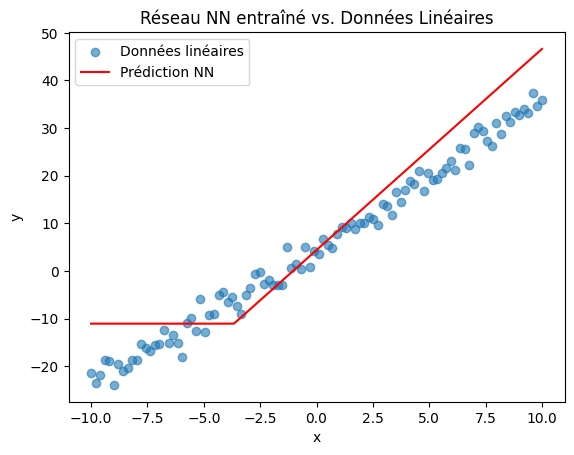

```python
x_test_lin = np.linspace(-10, 10, 200)
y_pred_lin = []
for xt in x_test_lin:
    y_pred_lin.append(func_nn(xt, W1_lin, b1_lin, W2_lin, b2_lin).data)

plt.figure()
plt.scatter(x_linear, y_linear, alpha=0.6, label="Données linéaires")
plt.plot(x_test_lin, y_pred_lin, 'r-', label="Prédiction NN")
plt.title("Réseau NN entraîné vs. Données Linéaires")
plt.xlabel("x")
plt.ylabel("y")
plt.legend()
plt.show()
```

### Entraînement du Réseau sur Données Non-Linéaires

On garde x_linear comme entrée, mais y_nonlinear comme cible.

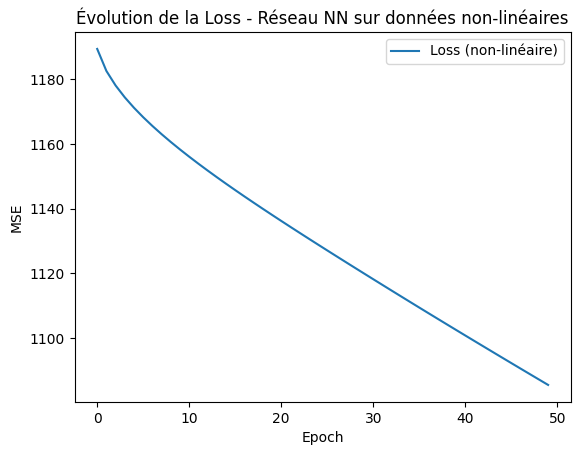

```
Paramètres appris (Données Non-Linéaires) :
W1 = 1.1431, b1 = 0.1599
W2 = -0.4073, b2 = 2.2924
```

```python
nb_iter_nn_nl = 50
optimizer_kwargs_nn_nl = {"learning_rate": 0.001}
optimizer_type_nn_nl = Adam  # par exemple

W1_nl, b1_nl, W2_nl, b2_nl, losses_nl = eval_nn_optim(
    x_linear,
    y_nonlinear,
    optimizer_kwargs=optimizer_kwargs_nn_nl,
    nb_iter=nb_iter_nn_nl,
    optimizer_type=optimizer_type_nn_nl
)

plt.figure()
plt.plot(losses_nl, label="Loss (non-linéaire)")
plt.title("Évolution de la Loss - Réseau NN sur données non-linéaires")
plt.xlabel("Epoch")
plt.ylabel("MSE")
plt.legend()
plt.show()

print("Paramètres appris (Données Non-Linéaires) :")
print(f"W1 = {W1_nl.data:.4f}, b1 = {b1_nl.data:.4f}")
print(f"W2 = {W2_nl.data:.4f}, b2 = {b2_nl.data:.4f}")
```

#### Visualisation de la fonction apprise (non-linéaire)

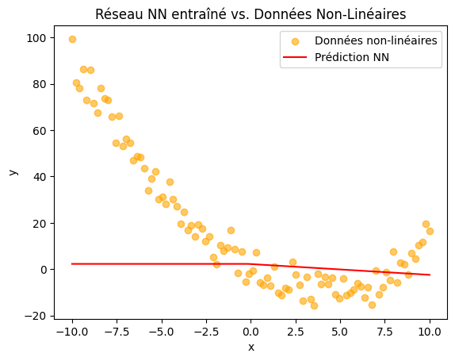

```python
x_test_nl = np.linspace(-10, 10, 200)
y_pred_nl = []
for xt in x_test_nl:
    y_pred_nl.append(func_nn(xt, W1_nl, b1_nl, W2_nl, b2_nl).data)

plt.figure()
plt.scatter(x_linear, y_nonlinear, color='orange', alpha=0.6, label="Données non-linéaires")
plt.plot(x_test_nl, y_pred_nl, 'r-', label="Prédiction NN")
plt.title("Réseau NN entraîné vs. Données Non-Linéaires")
plt.xlabel("x")
plt.ylabel("y")
plt.legend()
plt.show()
```

### Interpretation :

```
•	L’architecture utilisée (un seul neurone + ReLU) n’a pas la capacité d’apprendre des formes très non-linéaires.

•	Pour mieux approximer la courbe non-linéaire, il faudrait augmenter le nombre de neurones ou empiler plusieurs couches afin de gagner en expressivité.
```

### Comparaison Rapide de Différents Optimiseurs (Réseau, Données Linéaires)

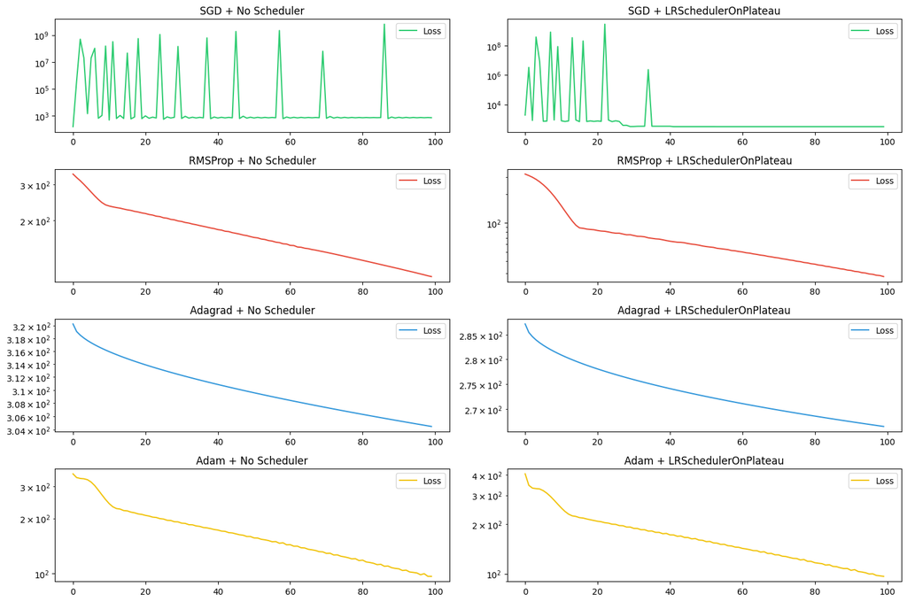

```python
def clip_gradients(tensor, min_val=-1e3, max_val=1e3):
    """Clip gradient values to prevent overflow"""
    if isinstance(tensor.grad, np.ndarray):
        tensor.grad = np.clip(tensor.grad, min_val, max_val)
    else:
        tensor.grad = max(min(tensor.grad, max_val), min_val)


optimizers = [SGD, RMSProp, Adagrad, Adam]
schedulers = [None, LRSchedulerOnPlateau]
colors = ['#2ecc71', '#e74c3c', '#3498db', '#f1c40f']

 def train_and_plot(optimizer_class, scheduler_class=None, lr=0.001, epochs=100):
    losses, lrs = [], []
    for epoch in range(epochs):
        total_loss = 0


        for x, y in zip(x_linear, y_linear):
            y_pred = func_nn(x, W1, b1, W2, b2)
            loss = mse(y_pred, y)
            loss.backward()


            for param in [W1, b1, W2, b2]:
                clip_gradients(param)

            optimizer.step()
            total_loss += loss.data

        avg_loss = total_loss / len(x_linear)
        losses.append(avg_loss)
        lrs.append(optimizer.learning_rate)


        if scheduler_class:
            if isinstance(scheduler, LRSchedulerOnPlateau):
                scheduler.step(avg_loss)
            else:
                scheduler.step()

    return losses, lrs

fig, axs = plt.subplots(len(optimizers), len(schedulers), figsize=(15, 10))
for i, optimizer_class in enumerate(optimizers):
    for j, scheduler_class in enumerate(schedulers):
        ax = axs[i, j]
        W1, b1, W2, b2 = Tensor(np.random.randn()), Tensor(0), Tensor(np.random.randn()), Tensor(0)
        optimizer = optimizer_class([W1, b1, W2, b2], learning_rate=0.001)
        scheduler = scheduler_class(optimizer, initial_lr=0.001) if scheduler_class else None
        losses, lrs = train_and_plot(optimizer_class, scheduler_class)
        ax.plot(losses, label='Loss', color=colors[i])
        ax.set_yscale('log')
        ax.set_title(f"{optimizer_class.__name__} + {scheduler_class.__name__ if scheduler_class else 'No Scheduler'}")
        ax.legend()

plt.tight_layout()
plt.show()
```

## Conclusion

### Analyse:

[output not shown]

##### Ce type de résultat illustre bien l’effet bénéfique du scheduler pour éviter la stagnation (ou l’explosion) et continuer à converger.